# PPM: Exploring 1<sup>st</sup> order effects

## Loading the data into R

Always remember to set the R session to the project folder where data are to be read from.

```r
# Load packages
# Note that rgdal should also be installed on your computer
# even though it's not explicitly called in the library function
library(spatstat)
library(maptools)
library(sf)
library(raster)

# Read state polygon data
s    <- st_read("MA.shp")
w    <- as.owin(s)
w.km <- rescale(w, 1000)

# Read Walmart point data
s    <- st_read("Walmarts.shp")
p    <- as.ppp(s)
p.km <- rescale(p, 1000)
marks(p.km)  <- NULL
Window(p.km) <- w.km

# Read population density raster
img         <- raster("pop_sqmile.tif")
pop         <- as.im(img)
pop.km      <- rescale(pop, 1000)
pop.km.log  <- log(pop.km)

# Read median income raster
img    <- raster("median_income.tif")
inc    <- as.im(img)
inc.km <- rescale(inc, 1000)
inc.km[] <- as.double(inc.km[]) # Convert integer income values to double values
```

You’ll note that we are converting the income raster from integer data type to double (`inc[] <- as.double(inc[])`). This is done to satisfy the `effectfun()` function that will be used later in this workflow–that function does *not* accept integer rasters.

You’ll also note in the above chunk of code that we are transforming population density values to logged values (`log(pop.km)`) because of the skewed nature of the population raster. This may help improve the model performance. Such transformation techniques are not uncommon in the field of statistics.

A quick way to check the distribution of raster pixel values is to plot the histogram as follows:

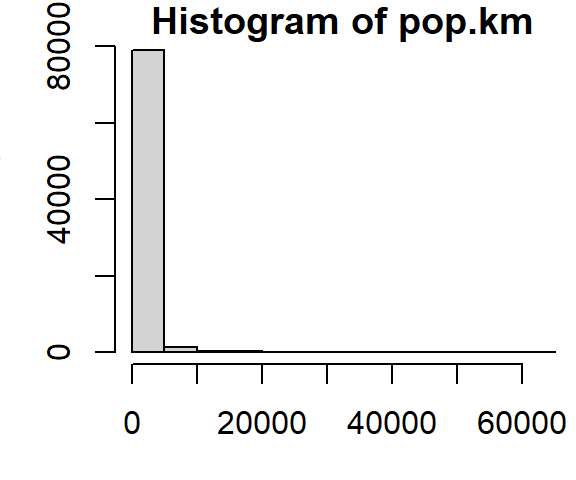

```r
# Plot original raster values
hist(pop.km)
```

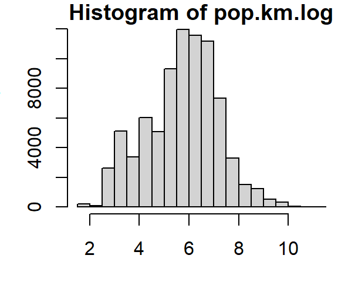

```r
# Plot log-transformed raster values
hist(pop.km.log)
```

Let’s plot each raster with the Walmart point overlay. We’ll use `R`’s base plotting environment.

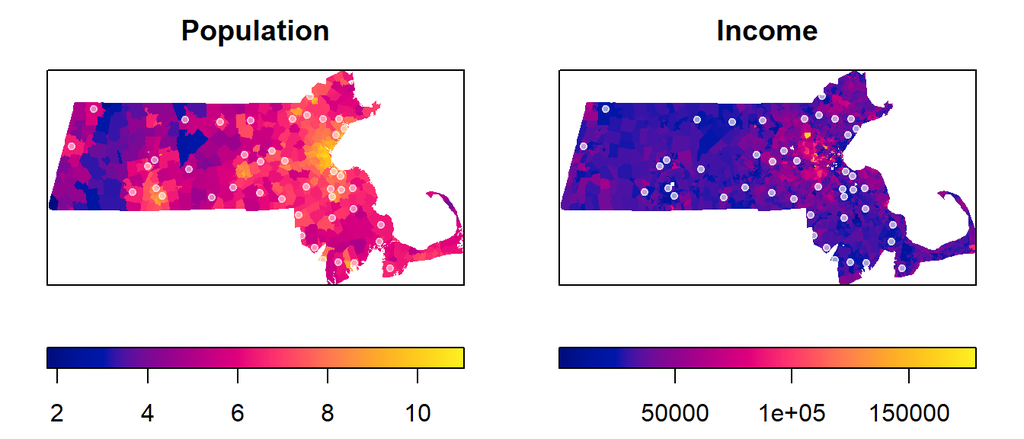

```r
plot(pop.km.log, ribside="bottom", main="Population")
plot(p.km, pch = 20, col=rgb(1,1,1,0.5), add=TRUE)

plot(inc.km, ribside="bottom", main="Income")
plot(p.km, pch = 20, col=rgb(1,1,1,0.6), add=TRUE)
```

## Modeling point density as a function of two competing covariates: population density and income.

We will first develop two different models that we think might define the Walmart’s point intensity. These models are defined by a couple of covariates: population distribution and income. These will be the alternate models that we’ll denote as `Mpop` and `Minc`. The models’ structure will follow the form of a logistics model, but note that the models can take on many different forms and different levels of complexity.

We’ll also create the null model, `Mo`, where we’ll assume a spatially uniform (homogeneous) covariate. In other words, `Mo` will define the model where we the intensity of the process is the same across the entire study extent.

```r
Mpop <- ppm(p.km ~ pop.km.log) # Population model
Minc <- ppm(p.km ~ inc.km)     # Income model
Mo   <- ppm(p.km ~ 1)          # Null model
```

Let’s explore the model parameters. First, we’ll look at `Mpop`.

```r
Mpop
```

```
## Nonstationary Poisson process
##
## Log intensity:  ~pop.km.log
##
## Fitted trend coefficients:
## (Intercept)  pop.km.log
##  -10.111647    0.625803
##
##               Estimate      S.E.     CI95.lo    CI95.hi Ztest       Zval
## (Intercept) -10.111647 0.7933272 -11.6665393 -8.5567540   *** -12.745872
## pop.km.log    0.625803 0.1127980   0.4047229  0.8468831   ***   5.547996
## Problem:
##  Values of the covariate 'pop.km.log' were NA or undefined at 3.4% (17 out of
## 504) of the quadrature points
```

The values of interest are the **intercept** (whose value is around `-10.1`) and the **coefficient** `pop.km.log` (whose value is around `0.63`). Using these values, we can construct the mathematical relationship (noting that we are using the logged population raster and not the original population raster values):

$$Walmart\ intensity(i)= e^{−10.1 + 0.63\ log(population\ density_i)}$$
The above equation can be interpreted as follows: if the population density is `0`, then the Walmart intensity is $e^{−10.1}$ which is very close to `0`. So for every unit increase of the *logged* population density (i.e. log of one person per square mile), there is a $e^{0.63}$ increase in Walmart intensity.

Likewise, we can extract the parameters from the `Minc` model and construct its equation.

```r
Minc
```

```
## Nonstationary Poisson process
##
## Log intensity:  ~inc.km
##
## Fitted trend coefficients:
##   (Intercept)        inc.km
## -5.576942e+00 -1.654792e-05
##
##                  Estimate         S.E.       CI95.lo       CI95.hi Ztest
## (Intercept) -5.576942e+00 5.258426e-01 -6.607574e+00 -4.546309e+00   ***
## inc.km      -1.654792e-05 1.490546e-05 -4.576209e-05  1.266624e-05
##                   Zval
## (Intercept) -10.605725
## inc.km       -1.110192
## Problem:
##  Values of the covariate 'inc.km' were NA or undefined at 3.2% (16 out of 504)
## of the quadrature points
```

$$Walmart\ intensity(i) = e^{−5.58\ −1.66e^{−5}\ Income(i)}$$
Note the negative (decreasing) relationship between income distribution and Walmart density.

Next, we’ll extract the null model results:

```r
Mo
```

```
## Stationary Poisson process
## Intensity: 0.002086305
##              Estimate      S.E.   CI95.lo   CI95.hi Ztest      Zval
## log(lambda) -6.172361 0.1507557 -6.467836 -5.876885   *** -40.94281
```

This gives us the following equation for the homogeneous process:

$$Walmart\ intensity(i) = e^{−6.17} = 0.00209$$

which is nothing more than the number of stores per unit area (44 stores / 21,000km<sup>2</sup> = 0.00209).

## Plotting the competing models

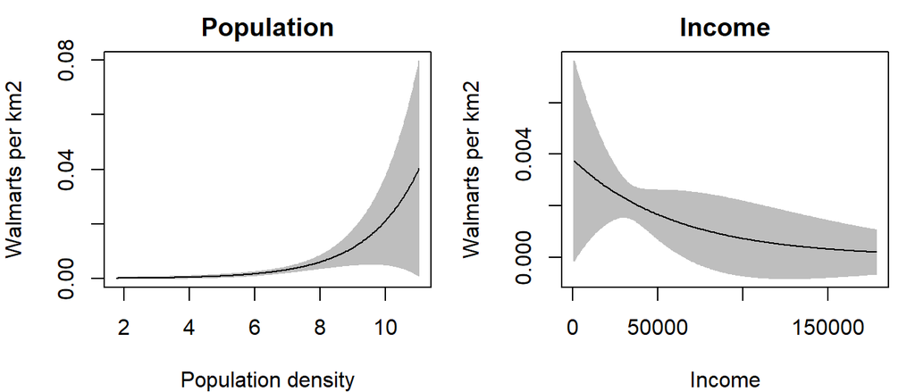

```r
OP <- par(mfrow = c(1,2), mar = c(4,4,2,1))  # This creates a two-pane plotting window

plot(effectfun(Mpop, "pop.km.log", se.fit = TRUE), main = "Population",
     ylab = "Walmarts per km2", xlab = "Population density", legend = FALSE)

plot(effectfun(Minc, "inc.km", se.fit = TRUE), main = "Income",
     ylab = "Walmarts per km2", xlab = "Income", legend = FALSE)

par(OP) # This reverts our plot window back to a one-pane window
```

Note the difference in relationships between the two models. In the first plot, we note an increasing relationship between Walmart intensity and population density; this is to be expected since you would not expect to see Walmart stores in underpopulated areas. In the second plot, we note an inverse relationship between Walmart intensity and income–-i.e. as an area’s income increases, the Walmart intensity decreases.

The grey envelopes encompass the 95% confidence interval; i.e. the true estimate (black line) can fall anywhere within this envelope. Note how the envelope broadens near the upper end of the population density values–this suggests wide uncertainty in the estimated model.

To assess how well the above models explain the relationship between covariate and Walmart intensity, we will turn to hypothesis testing.

## Testing for covariate effect

Now, let’s compare the non-homogeneous covariates to the null model using a technique called the *likelihood ratio* test. Remember that the null model assumes that the intensity is homogeneous across the entire study area; what we want to know is *“does the model with the covariate do a significantly better job in predicting Walmart densities than the null model?”*

```r
anova(Mo, Mpop, test = "LRT") # Compare null to population model
```

```
## Analysis of Deviance Table
##
## Model 1: ~1   Poisson
## Model 2: ~pop.km.log      Poisson
##   Npar Df Deviance  Pr(>Chi)
## 1   18
## 2   19  1   31.725 1.776e-08 ***
## ---
## Signif. codes:  0 '***' 0.001 '**' 0.01 '*' 0.05 '.' 0.1 ' ' 1
```

```r
anova(Mo, Minc, test = "LRT") # Compare null to income model
```

```
## Analysis of Deviance Table
##
## Model 1: ~1   Poisson
## Model 2: ~inc.km      Poisson
##   Npar Df Deviance Pr(>Chi)
## 1   17
## 2   18  1   1.3388   0.2473
```

What we are seeking is a small p-value (parameter `Pr(>Chi)` in the output). The smaller the value, the more confident we are in stating that the covariate does a better job in predicting Walmart intensity than the null model. For example, the p-value for the `Mpop` model (`Pr(>Chi) = 1.776e-08`) suggests that population density does a better job in predicting Walmart density than the null model `Mo`.

The p-value for `Minc`, on the other hand, is higher with a value of `Pr = 0.247` indicating that there is a 24.7% chance that we would be wrong in stating that income does a better job in predicting Walmart densities. To many, that probability is too high to reject the null.

So to summaries: of the two models we tested, it seems that population density does a better job at explaining the distribution of Walmarts (though it’s not perfect) than the null model. Income distribution, on the other hand, does not improve on the null model.

| Back to ES214 R scripts |  | *Manny Gimond, 2022* |
| --- | --- | --- |